# p8105_hw2_yl4923

## Problem 1

1.1 Clean Mr.Trash Wheel data

```r
trash_wheel = read_excel("data/Trash-Wheel-Collection-Totals-7-2020-2.xlsx", sheet = "Mr. Trash Wheel", range = "A2:N535") %>%
  janitor::clean_names() %>%
  drop_na(dumpster) %>%
  mutate(sports_balls = trunc(sports_balls))
```

1.2 Clean and joint precipitation datasets

```r
precip_2018 = read_excel("data/Trash-Wheel-Collection-Totals-7-2020-2.xlsx",sheet = "2018 Precipitation",range = "A2:B14") %>%
  mutate(year = "2018") %>%
  janitor::clean_names() %>%
  drop_na(total)

precip_2019 = read_excel("data/Trash-Wheel-Collection-Totals-7-2020-2.xlsx",sheet = "2019 Precipitation",range = "A2:B14") %>%
  mutate(year = "2019") %>%
  janitor::clean_names() %>%
  drop_na(total)

precip_df = bind_rows(precip_2019, precip_2018) %>%
  mutate(month = month.name[month]) %>%
  select(year,month,total)
```

Trash Wheel data shows the types of trash and their corresponding amounts collected by dumpsters from *2014* to *2020*, including 454 observations. Such as for one of the trashes, sports balls, the median of it in tons collected in 2019 is *9*. Over years, Mr. Trash Wheel collects *2899.4* tons of trash.

For precipitation data from 2019 and 2018,we are able to identify the original source of the data by creating *year* as a new variable.The precipitation data has 24 rows and 3 columns. The total precipitation in 2018 can be derived *70.33*.

### Problem 2

2.1 Make 3 datasets jointable

```r
party = c("dem", "gop", "gop")
pols_df = read_csv("data/fivethirtyeight_datasets/pols-month.csv") %>%
  janitor::clean_names() %>%
  separate(mon, into = c("year","month","day")) %>%
  mutate(month = month.name[as.integer(month)], president = party[prez_gop + 1]) %>%
  select(year,month,president,everything(),-day, -prez_dem, -prez_gop)
snp_df = read_csv("data/fivethirtyeight_datasets/snp.csv") %>%
  janitor::clean_names() %>%
  separate(date, into = c("month","day","year")) %>%
  mutate(month = month.name[as.integer(month)]) %>%
  select(year,month,close,-day)
unemp_df = read_csv("data/fivethirtyeight_datasets/unemployment.csv") %>%
  pivot_longer(Jan:Dec, names_to = "month", values_to = "unemploy_percentage") %>%
  mutate(Year = as.character(Year)) %>%
  select(year = Year,month,unemploy_percentage)
```

2.2 Merge *snp* into *pols*, and merging *unemployment* into the result.

```r
pols_snp_unemploy = left_join(pols_df, snp_df, by = c("year", "month")) %>%
  left_join(unemp_df, by = c("year", "month"))
```

The *pols_data* has 822 observations and 9 variables, describing the party of president, numbers of government officials in a given year. The *snp_data* contains 787 observations and 3 variables, showing the closing price of S&P overtime. The *unemployment data* with 816 observations and 3 variables gives the percentage of unemployment in certain month and year. The joint of all three data sets by *year* and *month* has 822 rows and 11 columns from 1947 to 2015. We then can examine the politics, S&P stock market and unemployment altogether in a specific month and year.

### Problem 3

3.1 Tidy the dataset

```r
babyname_df = read_csv("data/Popular_Baby_Names.csv") %>%
  janitor::clean_names() %>%
  mutate(gender = str_to_lower(gender), ethnicity = str_to_lower(ethnicity), ethnicity = replace(ethnicity, ethnicity == "asian and paci", "asian and pacific islander"),
    ethnicity = replace(ethnicity, ethnicity == "black non hisp", "black non hispanic"),
    ethnicity = replace(ethnicity, ethnicity == "white non hisp", "white non hispanic")) %>%
  distinct()
```

3.2 Popular name tables

```r
filter(babyname_df, gender == "female", childs_first_name == "Olivia") %>%
  select(year_of_birth, ethnicity, rank) %>%
  pivot_wider(names_from = "year_of_birth", values_from = "rank") %>%
  knitr::kable(format = "html", caption = "Popularity rank of “Olivia” as a female baby name over time")
```

Popularity rank of “Olivia” as a female baby name over time

| ethnicity | 2016 | 2015 | 2014 | 2013 |
| --- | --- | --- | --- | --- |
| asian and pacific islander | 1 | 1 | 1 | 3 |
| black non hispanic | 8 | 4 | 8 | 6 |
| hispanic | 13 | 16 | 16 | 22 |
| white non hispanic | 1 | 1 | 1 | 1 |

```r
filter(babyname_df, gender == "male", rank == "1") %>%
  select(year_of_birth, ethnicity, childs_first_name) %>%
  pivot_wider(names_from = "year_of_birth", values_from = "childs_first_name") %>%
  knitr::kable(format = "html", caption = "Most popular male children name over time")
```

Most popular male children name over time

| ethnicity | 2016 | 2015 | 2014 | 2013 | 2012 | 2011 |
| --- | --- | --- | --- | --- | --- | --- |
| asian and pacific islander | Ethan | Jayden | Jayden | Jayden | RYAN | ETHAN |
| black non hispanic | Noah | Noah | Ethan | Ethan | JAYDEN | JAYDEN |
| hispanic | Liam | Liam | Liam | Jayden | JAYDEN | JAYDEN |
| white non hispanic | Joseph | David | Joseph | David | JOSEPH | MICHAEL |

3.3 Scatter plot

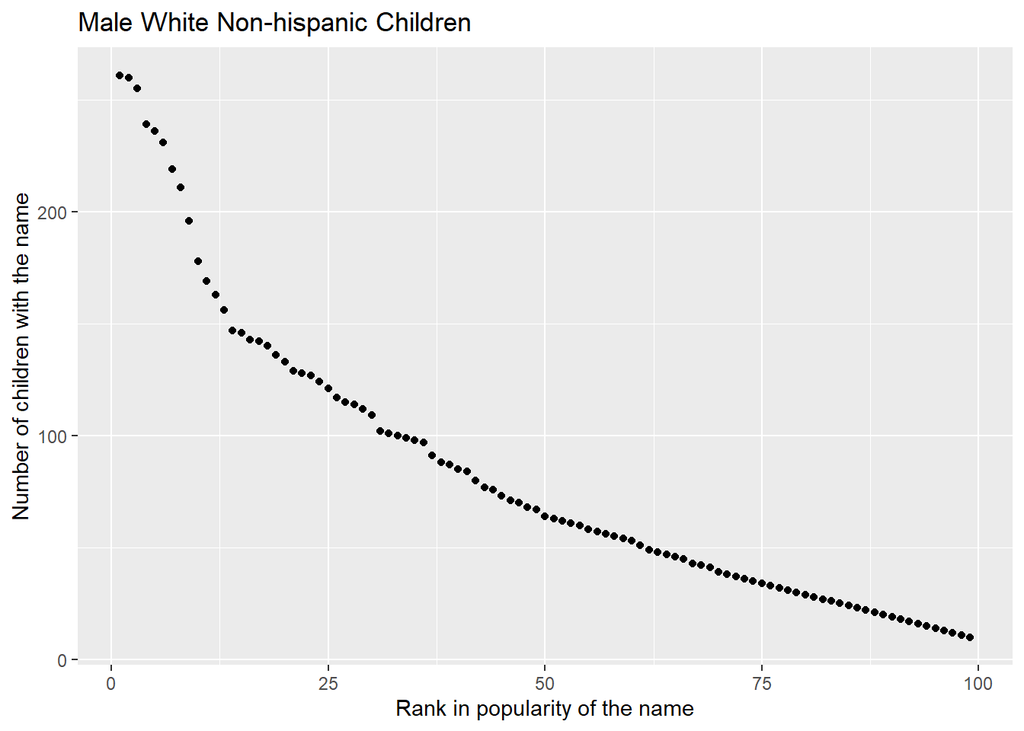

```r
scatterplot_df = filter(babyname_df, year_of_birth == "2016", gender == "male", ethnicity == "white non hispanic") %>%
  select(rank, count)

ggplot(scatterplot_df, aes(x = rank, y = count)) +
  geom_point() +
  labs(title = "Male White Non-hispanic Children", x = "Rank in popularity of the name", y = "Number of children with the name")
```